# Statistics in Python: Tests for Normality

⇦ Back

The code on this page uses the `numpy`, `scipy`, `pandas`, `statsmodels` and `matplotlib` packages. These can be installed from the terminal with:

```bash
$ python3.11 -m pip install numpy
$ python3.11 -m pip install scipy
$ python3.11 -m pip install pandas
$ python3.11 -m pip install statsmodels
$ python3.11 -m pip install matplotlib
```

where `python3.11` corresponds to the version of Python you have installed and are using.

Import these packages into Python with:

```python
import numpy as np
from scipy import stats as st
import pandas as pd
import statsmodels.api as sm
from matplotlib import pyplot as plt
```

For the statistical tests of normality, the hypotheses used are:

- $H_0$ : The sample is not significantly different than a normal population
- $H_1$ : The sample is significantly different than a normal population

We’ll use a significance level of 5% for the entire page:

```python
# Chosen the p-value below which will indicate significance
alpha = 0.05
```

# 1 Example Data: The Standard Normal Distribution

Set a seed for the random numbers:

```python
# Set the seed so that we get the same random numbers each time this code runs
np.random.seed(20230811)
```

Create and plot the example data:

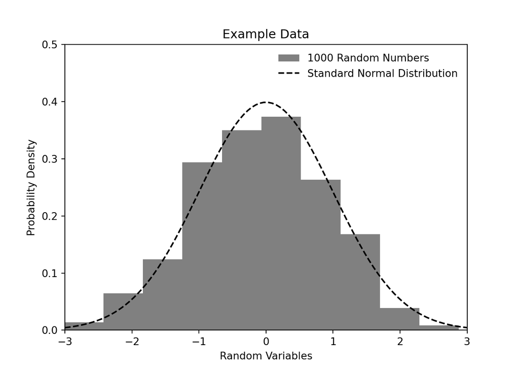

```python
# Draw random numbers from the standard normal distribution
mu, sigma = 0, 1
data = np.random.normal(mu, sigma, 1000)

# Plot the random numbers
label = '1000 Random Numbers'
plt.hist(data, density=True, color='gray', label=label)
# Plot the exact distribution
x = np.linspace(-3, 3, 100)
y = st.norm.pdf(x, mu, sigma)
plt.plot(x, y, 'k--', label='Standard Normal Distribution')
# Format
plt.title('Example Data')
plt.ylabel('Probability Density')
plt.xlabel('Random Variables')
plt.ylim([0, 0.5])
plt.xlim([-3, 3])
plt.legend(frameon=False)
plt.show()
```

## 1.1 D’Agostino’s (and Pearson’s) *K*-squared Test

See the documentation [here](https://docs.scipy.org/doc/scipy/reference/generated/scipy.stats.normaltest.html) and the Wikipedia page [here](https://en.wikipedia.org/wiki/D%27Agostino%27s_K-squared_test).

```python
statistic, p_value = st.normaltest(data)
if p_value > alpha:
    result = 'Normal'
else:
    result = 'NOT Normal'
print(f"D'Agostino & Pearson: {result:>11s}")
print(statistic)
```

```
## D'Agostino & Pearson:      Normal
## 4.612690205727473
```

## 1.2 Jarque-Bera Goodness-of-Fit Test

See the documentation [here](https://docs.scipy.org/doc/scipy/reference/generated/scipy.stats.jarque_bera.html) and the Wikipedia page [here](https://en.wikipedia.org/wiki/Jarque%E2%80%93Bera_test).

```python
statistic, pvalue = st.jarque_bera(data)
if pvalue > alpha:
    result = 'Normal'
else:
    result = 'NOT Normal'
print(f'Jarque-Bera: {result:>20s}')
print(statistic)
```

```
## Jarque-Bera:               Normal
## 3.880393602164786
```

## 1.3 Kolmogorov–Smirnov Test

Note that you cannot actually use the Kolmogorov-Smirnov test as a normality test; this function uses the Lilliefors test in the background (which is based on Kolmogorov-Smirnov).

See the documentation [here](https://www.statsmodels.org/stable/generated/statsmodels.stats.diagnostic.kstest_normal.html) (note that this is identical to the documentation for `lilliefors()`) and the Wikipedia page [here](https://en.wikipedia.org/wiki/Kolmogorov%E2%80%93Smirnov_test).

```python
ksstat, pvalue = sm.stats.diagnostic.kstest_normal(data)
if pvalue > alpha:
    result = 'Normal'
else:
    result = 'NOT Normal'
print(f'Kolmogorov-Smirnov: {result:>13s}')
print(ksstat)
```

```
## Kolmogorov-Smirnov:        Normal
## 0.0184928859912723
```

## 1.4 Lilliefors Test

The Lilliefors test is a Kolmogorov-Smirnov test with estimated parameters.

See the documentation [here](https://www.statsmodels.org/dev/generated/statsmodels.stats.diagnostic.lilliefors.html) (note that this is identical to the documentation for `kstest_normal()`) and the Wikipedia page [here](https://en.wikipedia.org/wiki/Lilliefors_test).

```python
ksstat, pvalue = sm.stats.diagnostic.lilliefors(data)
if pvalue > alpha:
    result = 'Normal'
else:
    result = 'NOT Normal'
print(f'Lilliefors: {result:>21s}')
print(ksstat)
```

```
## Lilliefors:                Normal
## 0.0184928859912723
```

Note that the test statistic (`ksstat`) is the same as the one for the Kolmogorov–Smirnov test.

## 1.5 Shapiro–Wilk Test

See the documentation [here](https://docs.scipy.org/doc/scipy/reference/generated/scipy.stats.shapiro.html) and the Wikipedia page [here](https://en.wikipedia.org/wiki/Shapiro%E2%80%93Wilk_test).

```python
statistic, pvalue = st.shapiro(data)
if pvalue > alpha:
    result = 'Normal'
else:
    result = 'NOT Normal'
print(f'Shapiro-Wilk: {result:>19s}')
print(statistic)
```

```
## Shapiro-Wilk:              Normal
## 0.9976267218589783
```

## 1.6 Anderson–Darling Test

This tests for whether data comes from a particular distribution.

See the documentation [here](https://docs.scipy.org/doc/scipy/reference/generated/scipy.stats.anderson.html) and the Wikipedia page [here](https://en.wikipedia.org/wiki/Anderson%E2%80%93Darling_test).

```python
result = st.anderson(data)
idx = np.where(result.significance_level == alpha * 100)
if result.statistic < result.critical_values[idx]:
    verdict = 'Normal'
else:
    verdict = 'NOT Normal'
print(f'Anderson–Darling: {verdict:>15s}')
print(result.statistic)
```

```
## Anderson–Darling:          Normal
## 0.4273934579834986
```

## 1.7 Probability Plot

A probability plot shows how closely two data sets agree. Types of probability plots include:

- P–P plots (probability-probability plots/percent-percent plots)
- Q–Q plots (quantile-quantile plots)
  - Normal probability plots (Q–Q plots against the standard normal distribution)

SciPy’s `probplot()` function can produce a probability plot, see the SciPy documentation [here](https://docs.scipy.org/doc/scipy/reference/generated/scipy.stats.probplot.html) and the Wikipedia disambiguation page [here](https://en.wikipedia.org/wiki/Probability_plot).

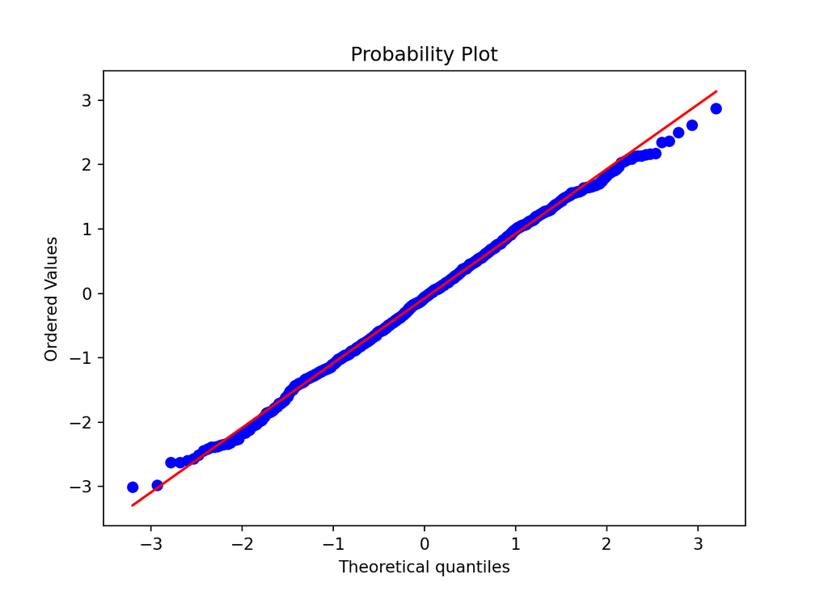

```python
st.probplot(data, dist='norm', plot=plt)
plt.show()
plt.close()
```

The easiest way to control the format of the plot is to take the objects that the function returns and plot those manually:

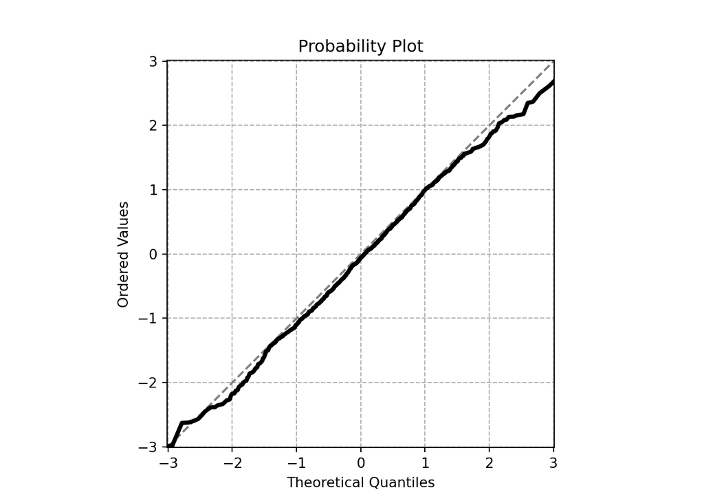

```python
ax = plt.axes()
ax.set_title('Probability Plot')
ax.set_ylabel('Ordered Values')
ax.set_xlabel('Theoretical Quantiles')
ax.axline((0, 0), slope=1, c='gray', ls='--')
ax.plot(*st.probplot(data, dist='norm')[0], c='k', lw=3)
axis_lim = max([abs(min(data)), max(data)])
ax.set_xlim([-axis_lim, axis_lim])
ax.set_ylim([-axis_lim, axis_lim])
ax.set_aspect('equal')
ax.grid(ls='--')
plt.show()
plt.close()
```

## 1.8 Q–Q Plot

A **quantile-quantile plot** shows the quantiles of two probability distributions. If the points lie close to or on the 45° line then it can be concluded that they are similar. This is a visual aid in testing for normality and should be checked in addition to the numerical test(s) because those do not tell you about behaviour at the tails.

Statsmodels has the `qqplot()` function that will create a Q–Q plot, see the documentation [here](https://www.statsmodels.org/stable/generated/statsmodels.graphics.gofplots.qqplot.html) and the Wikipedia page [here](https://en.wikipedia.org/wiki/Q%E2%80%93Q_plot).

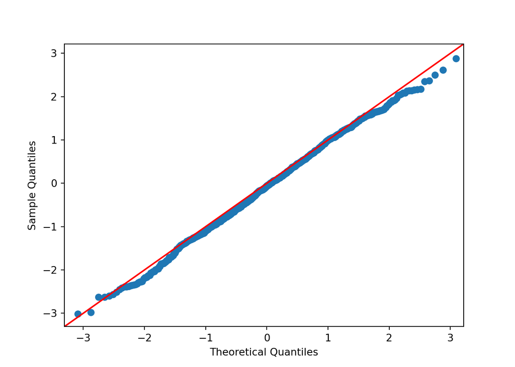

```python
sm.qqplot(data, line='45')
plt.show()
plt.close()
```

Controlling the format here is a bit tricky. The easiest way is probably to use the `ProbPlot()` function to create a probability plot that can then be plotted with `qqplot()` and `qqline()` to get a Q-Q plot. Use the `ax` keyword argument to use a Matplotlib Axes object:

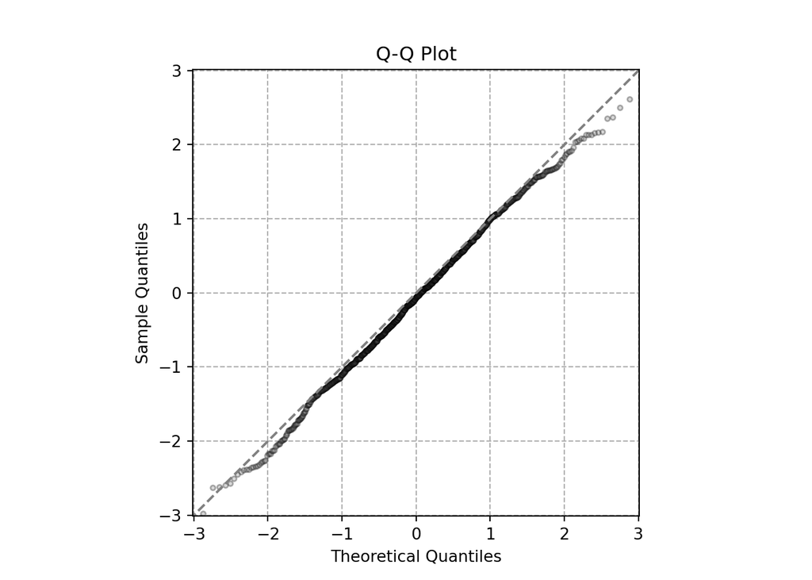

```python
ax = plt.axes()
ax.set_title('Q-Q Plot')
ax.set_ylabel('Sample Quantiles')
ax.set_xlabel('Theoretical Quantiles')
pp = sm.ProbPlot(data)
qq = pp.qqplot(marker='.', markerfacecolor='gray', markeredgecolor='k', alpha=0.3, ax=ax)
sm.qqline(qq.axes[0], line='45', color='gray', linestyle='--')
axis_lim = max([abs(min(data)), max(data)])
ax.set_xlim([-axis_lim, axis_lim])
ax.set_ylim([-axis_lim, axis_lim])
ax.set_aspect('equal')
ax.grid(ls='--')
plt.show()
plt.close()
```

# 2 Real-World Data: Mexican Population Densities

Taken from [here](http://webspace.ship.edu/pgmarr/Geo441/Lectures/Lec%205%20-%20Normality%20Testing.pdf).

```python
dct = {
    'Region': [
        'Ajuno', 'Angahuan', 'Arantepacua', 'Aranza', 'Charapan', 'Cheran',
        'Cocucho', 'Comachuen', 'Corupo', 'Ihuatzio', 'Janitzio', 'Jaracuaro',
        'Nahuatzen', 'Nurio', 'Paracho', 'Patzcuaro', 'Pichataro',
        'Pomacuaran', 'Quinceo', 'Quiroga', 'San Felipe', 'San Lorenzo',
        'Sevina', 'Tingambato', 'Turicuaro', 'Tzintzuntzan', 'Urapicho'
    ],
    'Population Density': [
        5.11, 5.15, 5.00, 4.13, 5.10, 5.22, 5.04, 5.25, 4.53, 5.74, 6.63, 5.73,
        4.77, 6.06, 4.82, 4.98, 5.36, 4.96, 5.94, 5.01, 4.10, 4.69, 4.97, 5.01,
        6.19, 4.67, 6.30
    ]
}
df = pd.DataFrame(dct)
print(df)
```

```
##           Region  Population Density
## 0          Ajuno                5.11
## 1       Angahuan                5.15
## 2    Arantepacua                5.00
## 3         Aranza                4.13
## 4       Charapan                5.10
## 5         Cheran                5.22
## 6        Cocucho                5.04
## 7      Comachuen                5.25
## 8         Corupo                4.53
## 9       Ihuatzio                5.74
## 10      Janitzio                6.63
## 11     Jaracuaro                5.73
## 12     Nahuatzen                4.77
## 13         Nurio                6.06
## 14       Paracho                4.82
## 15     Patzcuaro                4.98
## 16     Pichataro                5.36
## 17    Pomacuaran                4.96
## 18       Quinceo                5.94
## 19       Quiroga                5.01
## 20    San Felipe                4.10
## 21   San Lorenzo                4.69
## 22        Sevina                4.97
## 23    Tingambato                5.01
## 24     Turicuaro                6.19
## 25  Tzintzuntzan                4.67
## 26      Urapicho                6.30
```

## 2.1 Plot the Raw Data

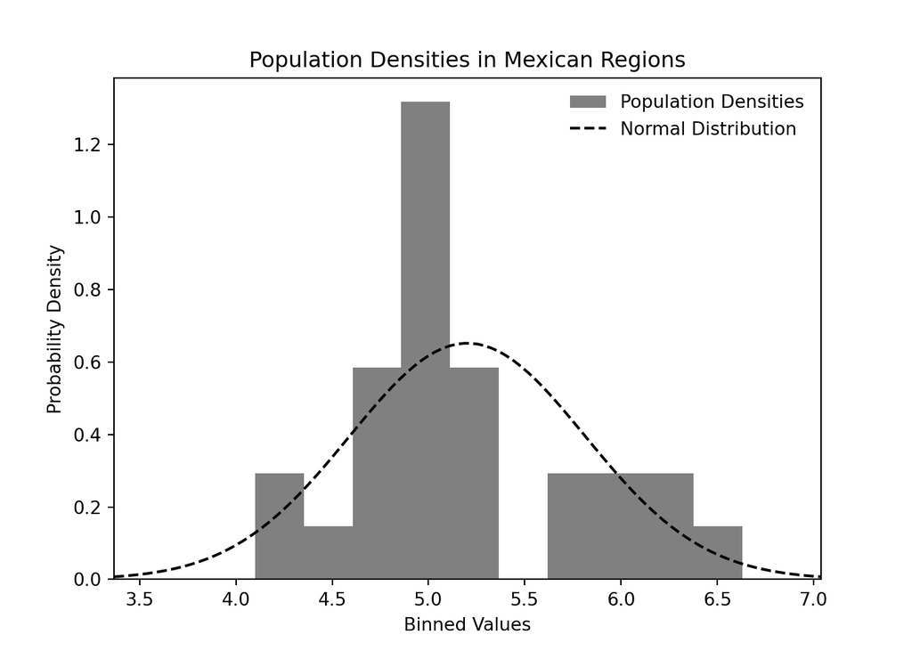

```python
# Plot the data
data = df['Population Density']
plt.hist(data, density=True, color='gray', label='Population Densities')
# Plot a normal distribution
x_bar = np.mean(data)
s = np.std(data)
x = np.linspace(x_bar - 3 * s, x_bar + 3 * s, 100)
y = st.norm.pdf(x, x_bar, s)
plt.plot(x, y, 'k--', label='Normal Distribution')
# Axes
plt.xlim([x_bar - 3 * s, x_bar + 3 * s])
# Finish
plt.title('Population Densities in Mexican Regions')
plt.ylabel('Probability Density')
plt.xlabel('Binned Values')
plt.legend(frameon=False)
plt.show()
plt.close()
```

## 2.2 Statistical Tests for Normality

```python
# D'Agostino's (and Pearson's) K² test
if st.normaltest(data)[1] > alpha:
    print("D'Agostino & Pearson:        Normal")
else:
    print("D'Agostino & Pearson:    NOT Normal")

# Jarque-Bera goodness-of-fit test
if st.jarque_bera(data)[1] > alpha:
    print('Jarque-Bera:                 Normal')
else:
    print('Jarque-Bera:             NOT Normal')

# Lilliefors test (based on the Kolmogorov–Smirnov test)
if sm.stats.diagnostic.lilliefors(data)[1] > alpha:
    print('Lilliefors:                  Normal')
else:
    print('Lilliefors:              NOT Normal')

# Shapiro–Wilk test
if st.shapiro(data)[1] > alpha:
    print('Shapiro-Wilk:                Normal')
else:
    print('Shapiro-Wilk:            NOT Normal')

# Anderson–Darling test
result = st.anderson(data)
if result[0] < result[1][2]:
    print('Anderson–Darling:            Normal')
else:
    print('Anderson–Darling:        NOT Normal')
```

```
## D'Agostino & Pearson:        Normal
## Jarque-Bera:                 Normal
## Lilliefors:              NOT Normal
## Shapiro-Wilk:                Normal
## Anderson–Darling:        NOT Normal
```

## 2.3 Compare to the Source

The [source](http://webspace.ship.edu/pgmarr/Geo441/Lectures/Lec%205%20-%20Normality%20Testing.pdf) performs seven statistical normality tests, two of which are the same (Lilliefors and Kolmogorov-Smirnov) and two of which are not implemented in Python (the W/S test - not to be confused with the Shapiro–Wilk test - and D’Agostino’s D test - not to be confused with D’Agostino’s *K*² test). The test statistics of the remaining four tests match those given by Python:

```python
print(f'Jarque–Bera test:      {st.jarque_bera(data)[0]:.3f}')
print(f'Lilliefors test:       {sm.stats.diagnostic.lilliefors(data)[0]:.3f}')
print(f'Shapiro–Wilk test:     {st.shapiro(data)[0]:.3f}')
print(f'Anderson–Darling test: {result.statistic:.3f}')
```

```
## Jarque–Bera test:      1.209
## Lilliefors test:       0.173
## Shapiro–Wilk test:     0.943
## Anderson–Darling test: 0.764
```

So our results match the source.

## 2.4 Graphical Tests for Normality

### 2.4.1 Probability Plot

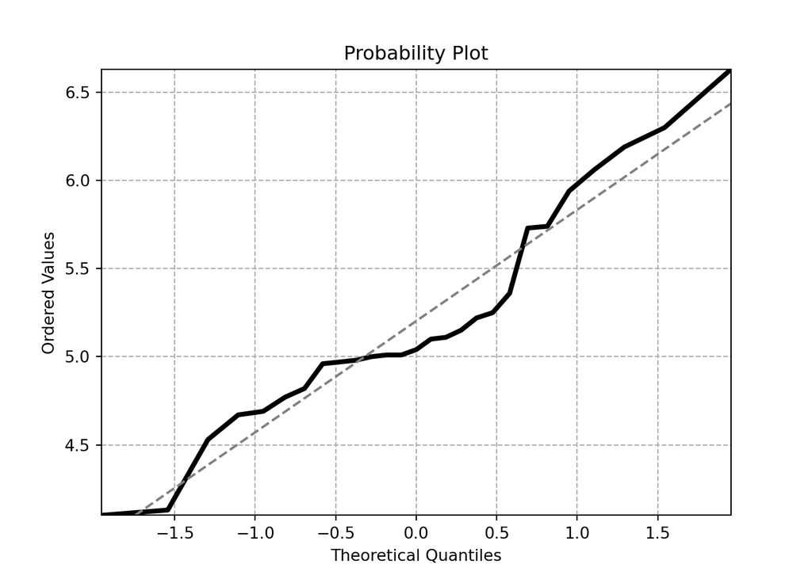

```python
ax = plt.axes()
ax.set_title('Probability Plot')
ax.set_ylabel('Ordered Values')
ax.set_xlabel('Theoretical Quantiles')
(osm, osr), (slope, intercept, r) = st.probplot(data, dist='norm')
ax.plot(osm, osr, c='k', lw=3)
ax.axline((0, intercept), slope=slope, c='gray', ls='--')
ax.set_ylim([min(osr), max(osr)])
ax.set_xlim([min(osm), max(osm)])
ax.grid(ls='--')
plt.show()
plt.close()
```

### 2.4.2 Q–Q Plot

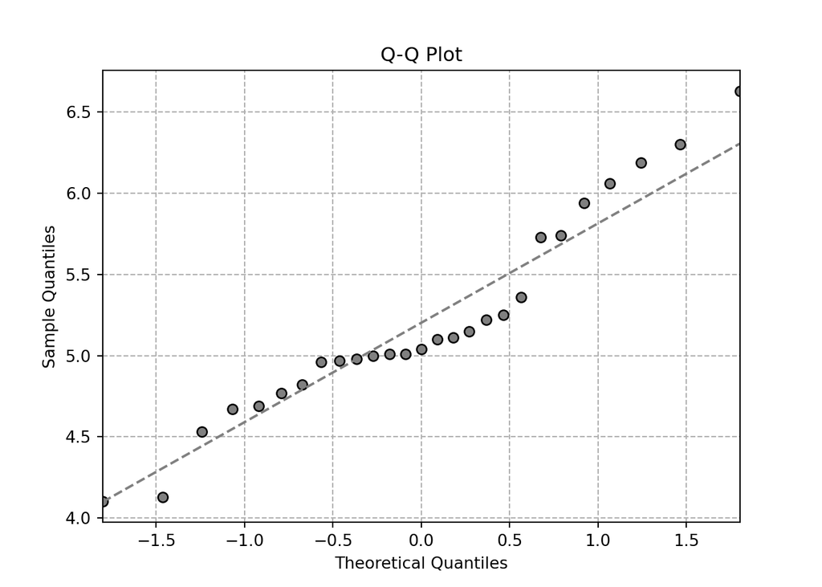

```python
ax = plt.axes()
ax.set_title('Q-Q Plot')
ax.set_ylabel('Sample Quantiles')
ax.set_xlabel('Theoretical Quantiles')
pp = sm.ProbPlot(data)
qq = pp.qqplot(markerfacecolor='gray', markeredgecolor='k', ax=ax)
x = pp.theoretical_quantiles
y = pp.sample_quantiles
sm.qqline(qq.axes[0], x=x, y=y, line='s', color='gray', linestyle='--')
ax.set_xlim([min(x), max(x)])
ax.grid(ls='--')
plt.show()
plt.close()
```

⇦ Back